# Desafio 11

Author

Maria Eduarda Villéla Silva

Este relatório foi compilado em: 07/10/2025 11:14:17.

```r
library(reticulate) #para usar o python no RStudio

#garantir que o reticulate vai usar o Python 3.12 que está presente nos pcs do lab
use_virtualenv("~/.virtualenvs/r-reticulate", required = TRUE)
py_run_string("import polars as pl; print(pl.__version__)")
```

```
1.33.1
```

```r
#instalar pacotes dentro desse Python, apenas se o chunk logo abaixo não funcionar
py_install("pip", pip = TRUE)
```

```
Using virtual environment "\\smb/ra212974/Documentos/.virtualenvs/r-reticulate" ...
```

```
+ "\\smb/ra212974/Documentos/.virtualenvs/r-reticulate/Scripts/python.exe" -m pip install --upgrade --no-user pip
```

```r
#py_install("numpy", pip = TRUE)
#py_install("pyarrow", pip = TRUE)
#py_install("polars[pyarrow]", pip = TRUE)
```

```python
#importando polars no RStudio
import polars as pl
```

1. Utilizando o arquivo `renda_adulta.csv` e sabendo que ele não possui cabeçalho, faça a importação do banco de dados utilizando os nomes das colunas conforme apresentado acima e na sequência ali indicada. No momento da importação do arquivo, você deve, também, indicar os tipos de cada uma das colunas. Utilize o fato de que o símbolo `?` representa valores faltantes.

```python
#definindo os nomes das colunas
nomes_colunas = [
    "idade", "classe_trabalho", "fnlwgt", "educacao", "num_educacao",
    "estado_civil", "ocupacao", "relacionamento", "raca", "sexo",
    "ganho_capital", "perda_capital", "horas_semanais", "pais_origem", "renda"]

#definição dos tipos de cada coluna
tipos_colunas = {
    "idade": pl.Int64,
    "classe_trabalho": pl.Utf8,
    "fnlwgt": pl.Int64,
    "educacao": pl.Utf8,
    "num_educacao": pl.Int64,
    "estado_civil": pl.Utf8,
    "ocupacao": pl.Utf8,
    "relacionamento": pl.Utf8,
    "raca": pl.Utf8,
    "sexo": pl.Utf8,
    "ganho_capital": pl.Int64,
    "perda_capital": pl.Int64,
    "horas_semanais": pl.Int64,
    "pais_origem": pl.Utf8,
    "renda": pl.Utf8}

#leitura do CSV sem cabeçalho, substituindo '?' por nulos
renda_adulta = pl.read_csv(
    "renda_adulta.csv",
    has_header = False,          #arquivo sem cabeçalho
    new_columns = nomes_colunas, #define os nomes
    schema_overrides = tipos_colunas,      #define os tipos
    null_values = "?"            #trata ? como valor faltante
)

#exibir as 5 primeiras linhas
print(renda_adulta.head())
```

```
shape: (5, 15)
┌───────┬──────────────┬────────┬───────────┬───┬──────────────┬─────────────┬─────────────┬───────┐
│ idade ┆ classe_traba ┆ fnlwgt ┆ educacao  ┆ … ┆ perda_capita ┆ horas_seman ┆ pais_origem ┆ renda │
│ ---   ┆ lho          ┆ ---    ┆ ---       ┆   ┆ l            ┆ ais         ┆ ---         ┆ ---   │
│ i64   ┆ ---          ┆ i64    ┆ str       ┆   ┆ ---          ┆ ---         ┆ str         ┆ str   │
│       ┆ str          ┆        ┆           ┆   ┆ i64          ┆ i64         ┆             ┆       │
╞═══════╪══════════════╪════════╪═══════════╪═══╪══════════════╪═════════════╪═════════════╪═══════╡
│ 39    ┆ State-gov    ┆ 77516  ┆ Bachelors ┆ … ┆ 0            ┆ 40          ┆ United-Stat ┆ <=50K │
│       ┆              ┆        ┆           ┆   ┆              ┆             ┆ es          ┆       │
│ 50    ┆ Self-emp-not ┆ 83311  ┆ Bachelors ┆ … ┆ 0            ┆ 13          ┆ United-Stat ┆ <=50K │
│       ┆ -inc         ┆        ┆           ┆   ┆              ┆             ┆ es          ┆       │
│ 38    ┆ Private      ┆ 215646 ┆ HS-grad   ┆ … ┆ 0            ┆ 40          ┆ United-Stat ┆ <=50K │
│       ┆              ┆        ┆           ┆   ┆              ┆             ┆ es          ┆       │
│ 53    ┆ Private      ┆ 234721 ┆ 11th      ┆ … ┆ 0            ┆ 40          ┆ United-Stat ┆ <=50K │
│       ┆              ┆        ┆           ┆   ┆              ┆             ┆ es          ┆       │
│ 28    ┆ Private      ┆ 338409 ┆ Bachelors ┆ … ┆ 0            ┆ 40          ┆ Cuba        ┆ <=50K │
└───────┴──────────────┴────────┴───────────┴───┴──────────────┴─────────────┴─────────────┴───────┘
```

```python
#verificar o esquema das colunas
print(renda_adulta.schema)
```

```
Schema({'idade': Int64, 'classe_trabalho': String, 'fnlwgt': Int64, 'educacao': String, 'num_educacao': Int64, 'estado_civil': String, 'ocupacao': String, 'relacionamento': String, 'raca': String, 'sexo': String, 'ganho_capital': Int64, 'perda_capital': Int64, 'horas_semanais': Int64, 'pais_origem':…
```

2. Apresente os tipos de cada uma das coluna.

```python
#mostrando o tipo de cada coluna
#o \n no início e no fim adiciona linhas em branco antes e depois da mensagem, para deixar a saída mais organizada

print("\nTipos de cada coluna:\n")
```

```
Tipos de cada coluna:
```

```python
for coluna, tipo in renda_adulta.schema.items():
    print(f"{coluna:<15} -> {tipo}")
```

```
idade           -> Int64
classe_trabalho -> String
fnlwgt          -> Int64
educacao        -> String
num_educacao    -> Int64
estado_civil    -> String
ocupacao        -> String
relacionamento  -> String
raca            -> String
sexo            -> String
ganho_capital   -> Int64
perda_capital   -> Int64
horas_semanais  -> Int64
pais_origem     -> String
renda           -> String
```

```python
#items() permite iterar sobre o dicionário, pegando pares (coluna, tipo)
#O for percorre todas as colunas do DataFrame
```

3. Apresente as dimensões da tabela de dados.

```python
#mostrando as dimensões
n_linhas, n_colunas = renda_adulta.shape
print(f"A tabela possui {n_linhas} linhas e {n_colunas} colunas.")
```

```
A tabela possui 32561 linhas e 15 colunas.
```

```python
#note que a saída printa uma frase bonitinha para apresentar o que foi pedido
```

4. Quantas pessoas recebem acima de $50.000 e quantas pessoas recebem abaixo deste limiar?

```python
#contando quantas pessoas estão acima e abaixo de 50K
contagem_renda = renda_adulta.group_by("renda").len()
print(contagem_renda) #printando na tela
```

```
shape: (2, 2)
┌───────┬───────┐
│ renda ┆ len   │
│ ---   ┆ ---   │
│ str   ┆ u32   │
╞═══════╪═══════╡
│ <=50K ┆ 24720 │
│ >50K  ┆ 7841  │
└───────┴───────┘
```

5. Crie um objeto chamado `renda_longo`, no qual você transforma as colunas `capital-gain` e `capital-loss` (formato wide) para formato longo. Os valores destas variáveis devem ser armazenados numa nova coluna chamada `Valor` e os tipos de valores (gain e loss) devem ser armazenados numa coluna chamada `tipo`.

```python
# remove espaços extras no início ou final dos valores da coluna 'renda'
# isso evita problemas como comparar '>50K ' com '>50K'
renda_adulta = renda_adulta.with_columns(
    pl.col("renda").str.strip_chars().alias("renda")
)

# transforma as colunas 'ganho_capital' e 'perda_capital' do formato wide → long
# melt() "empilha" essas duas colunas em uma só chamada 'Valor'
# e cria outra coluna chamada 'tipo' indicando se o valor vem de ganho ou perda
renda_longo = renda_adulta.unpivot(
    index = [
        "idade", "classe_trabalho", "fnlwgt", "educacao", "num_educacao",
        "estado_civil", "ocupacao", "relacionamento", "raca", "sexo",
        "horas_semanais", "pais_origem", "renda"
    ],                       # colunas que permanecem fixas
    on = ["ganho_capital", "perda_capital"],  # colunas que serão empilhadas
    variable_name="tipo",     # nova coluna que indica o tipo (ganho ou perda)
    value_name="Valor"        # nova coluna que armazena os valores numéricos
)

# substitui os nomes longos das variáveis por versões curtas
# "ganho_capital" → "gain"
# "perda_capital" → "loss"
renda_longo = renda_longo.with_columns(
    pl.col("tipo")
      .str.replace("ganho_capital", "gain")
      .str.replace("perda_capital", "loss")
)

#exibe as primeiras linhas do novo DataFrame em formato longo
print(renda_longo.head())
```

```
shape: (5, 15)
┌───────┬──────────────────┬────────┬───────────┬───┬───────────────┬───────┬──────┬───────┐
│ idade ┆ classe_trabalho  ┆ fnlwgt ┆ educacao  ┆ … ┆ pais_origem   ┆ renda ┆ tipo ┆ Valor │
│ ---   ┆ ---              ┆ ---    ┆ ---       ┆   ┆ ---           ┆ ---   ┆ ---  ┆ ---   │
│ i64   ┆ str              ┆ i64    ┆ str       ┆   ┆ str           ┆ str   ┆ str  ┆ i64   │
╞═══════╪══════════════════╪════════╪═══════════╪═══╪═══════════════╪═══════╪══════╪═══════╡
│ 39    ┆ State-gov        ┆ 77516  ┆ Bachelors ┆ … ┆ United-States ┆ <=50K ┆ gain ┆ 2174  │
│ 50    ┆ Self-emp-not-inc ┆ 83311  ┆ Bachelors ┆ … ┆ United-States ┆ <=50K ┆ gain ┆ 0     │
│ 38    ┆ Private          ┆ 215646 ┆ HS-grad   ┆ … ┆ United-States ┆ <=50K ┆ gain ┆ 0     │
│ 53    ┆ Private          ┆ 234721 ┆ 11th      ┆ … ┆ United-States ┆ <=50K ┆ gain ┆ 0     │
│ 28    ┆ Private          ┆ 338409 ┆ Bachelors ┆ … ┆ Cuba          ┆ <=50K ┆ gain ┆ 0     │
└───────┴──────────────────┴────────┴───────────┴───┴───────────────┴───────┴──────┴───────┘
```

6. Quais são as médias de horas trabalhadas por classe salarial?

```python
#calcular a média de horas por classe salarial
media_horas = (
    renda_adulta
    .group_by("renda")                  #agrupa pelos níveis de renda
    .agg(pl.col("horas_semanais").mean().alias("media_horas"))  #calcula média
)

#ordenar para ficar mais legível (opcional)
media_horas = media_horas.sort("renda")
#exibir o resultado
print(media_horas)
```

```
shape: (2, 2)
┌───────┬─────────────┐
│ renda ┆ media_horas │
│ ---   ┆ ---         │
│ str   ┆ f64         │
╞═══════╪═════════════╡
│ <=50K ┆ 38.84021    │
│ >50K  ┆ 45.473026   │
└───────┴─────────────┘
```

7. Se cada linha representa uma pessoa, quantas pessoas foram amostradas em cada profissão?

```python
#remover espaços extras na coluna 'ocupacao'
renda_adulta = renda_adulta.with_columns(
    pl.col("ocupacao").str.strip_chars().alias("ocupacao")
)

#contar o número de pessoas por ocupação
contagem_ocupacao = (
    renda_adulta
    .group_by("ocupacao")             #agrupa por profissão
    .agg(pl.len().alias("num_pessoas"))  #conta quantas linhas/pessoas em cada grupo
    .sort("num_pessoas", descending = True)     #opcional: ordena do maior para o menor
)

#exibir resultado
print(contagem_ocupacao)
```

```
shape: (15, 2)
┌─────────────────┬─────────────┐
│ ocupacao        ┆ num_pessoas │
│ ---             ┆ ---         │
│ str             ┆ u32         │
╞═════════════════╪═════════════╡
│ Prof-specialty  ┆ 4140        │
│ Craft-repair    ┆ 4099        │
│ Exec-managerial ┆ 4066        │
│ Adm-clerical    ┆ 3770        │
│ Sales           ┆ 3650        │
│ …               ┆ …           │
│ Farming-fishing ┆ 994         │
│ Tech-support    ┆ 928         │
│ Protective-serv ┆ 649         │
│ Priv-house-serv ┆ 149         │
│ Armed-Forces    ┆ 9           │
└─────────────────┴─────────────┘
```

8. Crie um gráfico de barras que apresente o número médio de horas trabalhadas semanalmente em função do nível salarial.

```python
#importando uma biblioteca necessária
import matplotlib
matplotlib.use("Agg")  #backend que não abre janelas, adequado para renderização em qmd
import matplotlib.pyplot as plt

#calculando a média de horas por nível salarial
media_horas = (
    renda_adulta
    .group_by("renda")
    .agg(pl.col("horas_semanais").mean().alias("media_horas"))
    .sort("renda")  # opcional: ordena alfabeticamente pelos níveis de renda
)

#convertendo para listas para o matplotlib
renda_labels = media_horas["renda"].to_list()
horas_medias = media_horas["media_horas"].to_list()

#criando o gráfico de barras
plt.figure(figsize=(8, 5))
plt.bar(renda_labels, horas_medias, color=["darkred", "darkblue"])
plt.title("Média de Horas Trabalhadas por Semana por Nível Salarial")
plt.xlabel("Nível Salarial")
plt.ylabel("Média de Horas Semanais")
plt.ylim(0, max(horas_medias) + 5)  # adiciona espaço acima das barras
```

```
(0.0, 50.473026399693914)
```

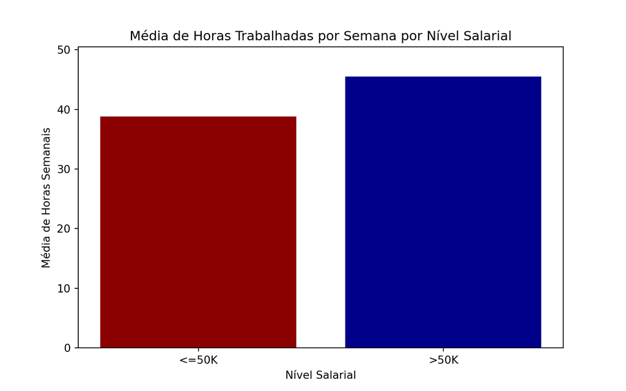

```python
plt.show()
```

9. Desafio: existe alguma evidência de discriminação salarial entre gêneros biológicos?

```python
#limpando espaços nas colunas de interesse
renda_adulta = renda_adulta.with_columns([
    pl.col("renda").str.strip_chars().alias("renda"),
    pl.col("sexo").str.strip_chars().alias("sexo")
])

#contando pessoas acima e abaixo de 50k por gênero
contagem_sexo_renda = (
    renda_adulta
    .group_by(["sexo", "renda"])
    .agg(pl.len().alias("quantidade"))
    .sort(["sexo", "renda"]))
print("\nTabela 1: Contagem de pessoas por gênero e classe salarial")
```

```
Tabela 1: Contagem de pessoas por gênero e classe salarial
```

```python
print(contagem_sexo_renda) #isso mostra, para cada gênero, quantas pessoas estão acima ou abaixo de 50K
```

```
shape: (4, 3)
┌────────┬───────┬────────────┐
│ sexo   ┆ renda ┆ quantidade │
│ ---    ┆ ---   ┆ ---        │
│ str    ┆ str   ┆ u32        │
╞════════╪═══════╪════════════╡
│ Female ┆ <=50K ┆ 9592       │
│ Female ┆ >50K  ┆ 1179       │
│ Male   ┆ <=50K ┆ 15128      │
│ Male   ┆ >50K  ┆ 6662       │
└────────┴───────┴────────────┘
```

```python
#calculando proporção de renda por gênero
#total por gênero
total_por_genero = (
    renda_adulta.group_by("sexo")
    .agg(pl.len().alias("total"))
)

#pessoas com renda >50K
acima_50k = (
    renda_adulta.filter(pl.col("renda") == ">50K")
    .group_by("sexo")
    .agg(pl.len().alias("acima_50k"))
)

#unir e calcular proporção
proporcao = total_por_genero.join(acima_50k, on="sexo", how="left").with_columns(
    (pl.col("acima_50k") / pl.col("total") * 100).alias("perc_acima_50k")
)
print("\nTabela 2: Proporção de pessoas com renda >50K")
```

```
Tabela 2: Proporção de pessoas com renda >50K
```

```python
print(proporcao)
```

```
shape: (2, 4)
┌────────┬───────┬───────────┬────────────────┐
│ sexo   ┆ total ┆ acima_50k ┆ perc_acima_50k │
│ ---    ┆ ---   ┆ ---       ┆ ---            │
│ str    ┆ u32   ┆ u32       ┆ f64            │
╞════════╪═══════╪═══════════╪════════════════╡
│ Male   ┆ 21790 ┆ 6662      ┆ 30.573658      │
│ Female ┆ 10771 ┆ 1179      ┆ 10.946059      │
└────────┴───────┴───────────┴────────────────┘
```

Segundo a `Tabela 1`, é notável que Uma proporção maior de homens está na classe salarial >50K, enquanto mulheres têm menos representantes na faixa salarial alta.

De acordo com a `Tabela 2`, a proporção de pessoas com renda >50K é maior para homens comparado a mulheres. Em termos absolutos, mais homens ganham >50K, refletindo desigualdade salarial na amostra.